# Biomarker Prognostic Enrichment Tool for Clinical Trial with Survival Outcomes

A tutorial for (hopefully soon-to-come) R package SurvPET

Si Cheng

March 25, 2019

Prognostic Enrichment is a clinical trial strategy of evaluating an intervention in a patient population with a higher rate of the unwanted event than the broader patient population (R. Temple (2010) DOI:10.1038/clpt.2010.233). A higher event rate translates to a lower sample size for the clinical trial, which can have both practical and ethical advantages. The package `SurvPET` provides tools to evaluate biomarkers for prognostic enrichment of clinical trials with survival or time-to-event outcomes. (Most parts of this paragraph come from the documentation of `BioPET`)

Key functions of this package are:

- `surv_enrichment`: Estimate trial characteristics at different levels of enrichment, given a biomarker (which can be a single biomarker or a composite)
- `surv_plot_enrichment`: Visualize trial characteristics returned by `surv_enrichment`

### Loading the functions and simulated data

```r
source("https://raw.githubusercontent.com/chengs94/SurvPET/master/surv_enrichment.R")
source("https://raw.githubusercontent.com/chengs94/SurvPET/master/surv_plot_enrichment.R")
load("sim_data.RData")
head(sim.data)
```

```
##            x1         x2      surv
## 1 -0.13340198 -1.4857479 70.34040+
## 2 -0.12841165  2.2937339  14.15657
## 3 -0.15231202 -1.8823037 92.25437+
## 4 -0.15062909 -0.9079110 96.62410+
## 5 -0.13581394 -1.4912749 77.58120+
## 6 -0.03599418 -0.3659589 50.14999+
```

The simulated dataset contains 1533 observations of three variables: two biomarkers ($X_1$ and $X_2$) and the survival outcome (time to event and indicator of event).

### Prognostic enrichment with real data

To call `surv_enrichment`:

```
surv_enrichment(formula, data, hr = 0.8, end.of.trial=NULL, a=NULL, f=NULL,
               cost.screening = NULL, cost.keeping = NULL, cost.unit.keeping = NULL,
               power = 0.9, alpha = 0.05, one.sided = F,
               selected.biomarker.quantiles = seq(from = 0, to = 0.95, by = 0.05),
               do.bootstrap = FALSE, n.bootstrap = 1000, seed = 2333,
               print.summary.tables = FALSE)
```

This function applies to two types of trials.

- All patients are recruited at time 0 and followed to the end of trial (given by `end.of.trial`, which can be a scalar or vector. If the user inputs a vector of time points, analysis will be done separately for each time point in the vector).
  - If `cost.keeping` and `cost.screening` are specified, it is assumed that the cost for keeping one patient through the trial is *fixed*, and equals `cost.keeping`. Standard errors are computed analytically (except for the reduction in cost).
  - If `cost.unit.keeping` and `cost.screening` are specified, it is assumed that a patient is excluded from the trial (i.e. no longer costs) if a clinical event occurs. In this case, `cost.unit.keeping` is the cost for keeping one patient *per unit time*. Standard errors are computed analytically (except for cost and reduction in cost).
  - In either case, the length of `cost.keeping` or `cost.unit.keeping` must be the same as `end.of.trial`, and each entry corresponds to the cost for trials with a certain duration. Bootstrap will not be conducted in either case.
- Another type of trial has an accrual period `a` and a follow-up period `f` (so that the patients are followed for between `f` and `a+f` units of time). The methodology makes the standard assumption of uniform enrollment of patients during the accrual period.
  - If `cost.keeping` and `cost.screening` are specified, the former corresponds to the *average/median* cost for one patient under such design, and is used for all patients in the trial.
  - If `cost.unit.keeping` and `cost.screening` are specified, the former corresponds to the cost *per unit time* for one patient, and we assume each patient is in the trial from recruitment until the clinical event (i.e. no longer costs after a clinical event).
  - In either scenario, no analytic formula for standard error is available. Bootstrap standard errors are computed if `do.bootstrap = T` is specified.

Explanation for arguments (all are required if not specified otherwise):

- `formula` should be of the form `outcome ~ covariate1 + covariate2 +...`. If multiple covariates are inputed, the package will consider a combined “biomarker” based on a Cox model with all covariates.
- `data` the data frame containing at least a survival outcome (as returned by `Surv`) and observations of one biomarker
- `hr` is the hazard ratio that the trial seeks to detect. Should be between 0 and 1.
- `end.of.trial` (optional) can be either a scalar or a vector. It gives the duration of a fixed-length trial. Either `end.of.trial` or a combination of `a` and `f` must be specified.
- `a` and `f` (optional) are the accrual and follow-up periods respectively. Must be scalar. Either `a` and `f`, or `end.of.trial`, must be specified.
- `cost.screening`, `cost.keeping` and `cost.unit.keeping` (optional) are the costs as explained above. If either `cost.screening`, or both of `cost.keeping` and `cost.unit.keeping` are not specified, costs will not be computed. If both `cost.keeping` and `cost.unit.keeping` are specified, `cost.unit.keeping` is ignored by default.
- `power` and `alpha` correspond to the desired power and type I error rate of the trial. Should both be between 0 and 1.
- `one.sided` (optional) is an indicator of whether the test is one-sided. Default is `FALSE`.
- `selected.biomarker.quantiles` are the levels of enrichment that the user wants to compare.
- `do.bootstrap`, `n.bootstrap` and `seed` (optional) are arguments corresponding to bootstrap for trials with accrual and follow-up. If `do.bootstrap=F`, bootstrap will not be conducted.
- `print.summary.tables` (optional) is an indicator of whether a summary table for trial characteristics should be printed. Default is `FALSE`.

Example 1: Use biomarker `x1` to enrich the trial, and consider trials lasting 36 and 48 months respectively. All patients are followed for the same duration. The cost for measuring one patient’s biomarker level is 50, and the costs for one patient in a 36 and 48-month trial are 800 and 1000 respectively.

```r
result1 <- surv_enrichment(formula = surv~x1, sim.data, hr = 0.8, end.of.trial = c(36,48),
                           cost.screening = 50, cost.keeping = c(800,1000),
                           power = 0.9, alpha = 0.05, one.sided = F,
                           selected.biomarker.quantiles = seq(from = 0, to = 0.98, by = 0.02),
                           print.summary.tables = F)
names(result1)
```

```
##  [1] "summary.table"                "event.prob"
##  [3] "event.prob.sd"                "n.patients"
##  [5] "n.patients.sd"                "num.screened"
##  [7] "num.screened.sd"              "total.cost"
##  [9] "total.cost.sd"                "cost.reduction"
## [11] "cost.reduction.sd"            "response"
## [13] "biomarker"                    "biomarker.name"
## [15] "selected.biomarker.quantiles" "end.of.trial"
## [17] "a"                            "f"
## [19] "acc.fu"
```

The output is a list with the contents above. The first argument is the table with summary statistics. The 2nd to 11th elements are estimates and standard errors for: 1) event probability at the end of trial; 2) sample size required; 3) total number of patients to measure for biomarker levels to achieve such sample size; 4) total cost (screening + trial); 5) reduction (%) in cost comparing to no enrichment. These are all matrices, where each row corresponds to one enrichment level, and the columns correspond to different duration of trials.

The last 8 arguments correspond to the input of user. `acc.fu` is an indicator of whether this trial is considered as type “accrual + follow-up”.

Example 2: Use biomarker `x2` to enrich the trial, which has an accrual period of 24 months and a follow-up period of 24 months. A patient will no longer be in the trial (i.e. no longer costs) after experiencing an event. The cost per month for one patient is 20. Bootstrap standard errors are computed with 200 bootstrap samples (only for illustration, we do not generate a large number of bootstrap draws).

```r
result2 <- surv_enrichment(formula = surv~x2, sim.data, hr = 0.8, a=24, f=24,
                           cost.screening = 50, cost.unit.keeping = 20,
                           power = 0.9, alpha = 0.05, one.sided = F,
                           selected.biomarker.quantiles = seq(from = 0, to = 0.98, by = 0.02),
                           do.bootstrap = T, n.bootstrap = 200, seed = 233,
                           print.summary.tables = T)
```

```
##       level.enrichment      prob     prob.sd n.patients n.patients.sd
##  [1,]             0.00 0.1349444 0.008230102       6905     438.23055
##  [2,]             0.02 0.1379914 0.008428240       6751     429.13341
##  [3,]             0.04 0.1411182 0.008607123       6601     418.84629
##  [4,]             0.06 0.1444435 0.008825569       6448     410.21078
##  [5,]             0.08 0.1480695 0.009035266       6289     400.12676
##  [6,]             0.10 0.1515140 0.009241890       6145     390.14158
##  [7,]             0.12 0.1551965 0.009468272       5998     380.62343
##  [8,]             0.14 0.1593895 0.009750972       5839     371.94252
##  [9,]             0.16 0.1638334 0.010011943       5679     361.55906
## [10,]             0.18 0.1682995 0.010271665       5527     351.40647
## [11,]             0.20 0.1723291 0.010373984       5397     337.62629
## [12,]             0.22 0.1771445 0.010791740       5249     333.39711
## [13,]             0.24 0.1821009 0.011127906       5104     325.24211
## [14,]             0.26 0.1876658 0.011486403       4952     316.59760
```

[output cut: 87 more lines]

### Visualizing results from an enrichment analysis

The function `surv_plot_enrichment` makes a set of plots based on an object `x` returned by `surv_enrichment`. To call this function:

```
surv_plot_enrichment(x, km.quantiles = c(0,0.25,0.5,0.75),
                    km.range = NULL, alt.color = NULL)
```

`km.quantiles` are the levels of enrichment that the user wants to compare in Kaplan-Meier survival curves. `km.range` is the range of time in Kaplan-Meier survival plot (taken as the last time point of observation by default). `alt.color` allows the user to specify the color of curves (taken as default `ggplot2` colors if not specified).

If multiple durations of trials are considered to obtain `x`, they will be plotted together for comparison. In this situation, the length of `alt.color` must match that of `end.of.trial`. If the user wishes to compare multiple biomarkers/power of trial in the same sets of plots, they can use the outputs from `surv_enrichment` and manually construct the plots.

If `x` contains standard error estimates, error bars will be added to the plots.

Example 1 cont’d: plots with customized color

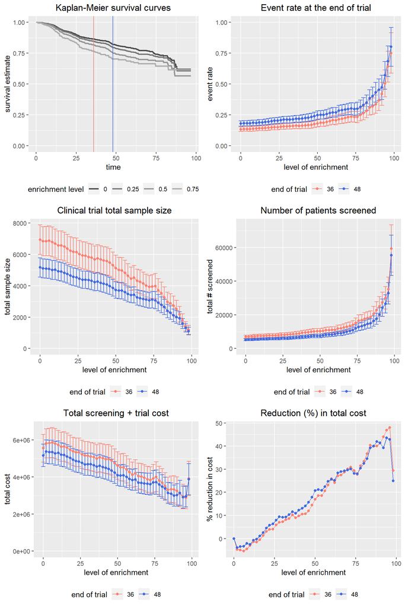

```r
plots1 <- surv_plot_enrichment(result1, alt.color = c("salmon","royalblue"))
```

```r
names(plots1)
```

```
## [1] "km.plot"             "prob.plot"           "ss.plot"
## [4] "screen.plot"         "cost.plot"           "reduction.cost.plot"
## [7] "summary"
```

This function returns six plots: 1) Kaplan-Meier survival curves of patients with biomarker levels above certain quantiles; 2) event rate at the end of trial; 3) sample size required; 4) number of patients that need to be screened; 5) screening + trial cost; 6) reduction in cost. A combination of these six plots will automatically be printed (as above).

Example 2 cont’d: use range $t=0$ to $t=60$ in Kaplan-Meier plot

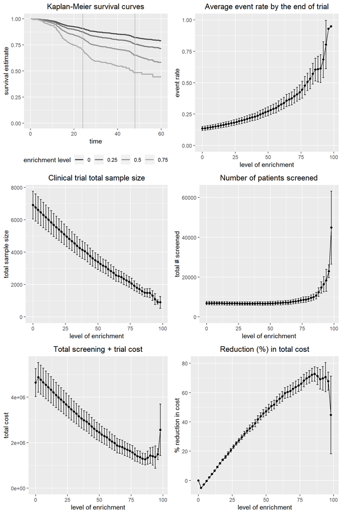

```r
plots2 <- surv_plot_enrichment(result2, km.range = 60)
```

We then conduct a call similar to Example 2, except that biomarker `x1` is used. Manually plotting `result2` and this result together gives:

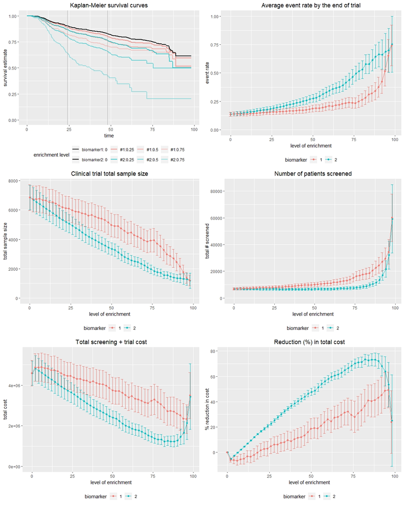